# INFX 574

# Problem Set 1

```python
#IPython is what you are using now to run the notebook
import IPython
print ("IPython version:      %6.6s (need at least 1.0)" % IPython.__version__)

# Numpy is a library for working with Arrays
import numpy as np
print ("Numpy version:        %6.6s (need at least 1.7.1)" % np.__version__)

# SciPy implements many different numerical algorithms
import scipy as sp
print ("SciPy version:        %6.6s (need at least 0.12.0)" % sp.__version__)

# Pandas makes working with data tables easier
import pandas as pd
print ("Pandas version:       %6.6s (need at least 0.11.0)" % pd.__version__)

# Module for plotting
import matplotlib
print ("Mapltolib version:    %6.6s (need at least 1.2.1)" % matplotlib.__version__)

# SciKit Learn implements several Machine Learning algorithms
import sklearn
print ("Scikit-Learn version: %6.6s (need at least 0.13.1)" % sklearn.__version__)
```

```
IPython version:       5.1.0 (need at least 1.0)
Numpy version:        1.11.3 (need at least 1.7.1)
SciPy version:        0.18.1 (need at least 0.12.0)
Pandas version:       0.19.2 (need at least 0.11.0)
Mapltolib version:     2.0.0 (need at least 1.2.1)
Scikit-Learn version: 0.18.1 (need at least 0.13.1)
```

## About the Problem Set:

This is the same problem set used by Emma Spiro in INFX573. The only difference is that instead of doing the problem set in R, you will use Python and the IPython notebook.

## Instructions:

In this problem set you will perform a basic exploratory analysis on an example dataset, bringing to bear all of your new skills in data manipulation and visualization. You will be required to submit well commented python code, documenting all code used in this problem set, along with a write up answering all questions below. Use figures as appropriate to support your answers, and when required by the problem. This data set uses the NYCFlights13 dataset. You can download the dataset from canvas.

```python
import pandas as pd
import numpy as np
import matplotlib.pyplot as plt

matplotlib.style.use('ggplot')
```

```python
flights_df= pd.read_csv('flights.csv')
matplotlib.style.use('ggplot')
```

```python
print("shape", flights_df.shape)
print("columns", flights_df.columns)
print("types", flights_df.dtypes)
```

```
shape (336776, 17)
columns Index(['Unnamed: 0', 'year', 'month', 'day', 'dep_time', 'dep_delay',
       'arr_time', 'arr_delay', 'carrier', 'tailnum', 'flight', 'origin',
       'dest', 'air_time', 'distance', 'hour', 'minute'],
      dtype='object')
types Unnamed: 0      int64
year            int64
month           int64
day             int64
dep_time      float64
dep_delay     float64
arr_time      float64
arr_delay     float64
carrier        object
tailnum        object
flight          int64
origin         object
dest           object
air_time      float64
distance        int64
hour          float64
minute        float64
dtype: object
```

```python
flights_df.dest.unique()
flights_df.head(10)
```

|  | Unnamed: 0 | year | month | day | dep_time | dep_delay | arr_time | arr_delay | carrier | tailnum | flight | origin | dest | air_time | distance | hour | minute |
| --- | --- | --- | --- | --- | --- | --- | --- | --- | --- | --- | --- | --- | --- | --- | --- | --- | --- |
| 0 | 1 | 2013 | 1 | 1 | 517.0 | 2.0 | 830.0 | 11.0 | UA | N14228 | 1545 | EWR | IAH | 227.0 | 1400 | 5.0 | 17.0 |
| 1 | 2 | 2013 | 1 | 1 | 533.0 | 4.0 | 850.0 | 20.0 | UA | N24211 | 1714 | LGA | IAH | 227.0 | 1416 | 5.0 | 33.0 |
| 2 | 3 | 2013 | 1 | 1 | 542.0 | 2.0 | 923.0 | 33.0 | AA | N619AA | 1141 | JFK | MIA | 160.0 | 1089 | 5.0 | 42.0 |
| 3 | 4 | 2013 | 1 | 1 | 544.0 | -1.0 | 1004.0 | -18.0 | B6 | N804JB | 725 | JFK | BQN | 183.0 | 1576 | 5.0 | 44.0 |
| 4 | 5 | 2013 | 1 | 1 | 554.0 | -6.0 | 812.0 | -25.0 | DL | N668DN | 461 | LGA | ATL | 116.0 | 762 | 5.0 | 54.0 |
| 5 | 6 | 2013 | 1 | 1 | 554.0 | -4.0 | 740.0 | 12.0 | UA | N39463 | 1696 | EWR | ORD | 150.0 | 719 | 5.0 | 54.0 |
| 6 | 7 | 2013 | 1 | 1 | 555.0 | -5.0 | 913.0 | 19.0 | B6 | N516JB | 507 | EWR | FLL | 158.0 | 1065 | 5.0 | 55.0 |
| 7 | 8 | 2013 | 1 | 1 | 557.0 | -3.0 | 709.0 | -14.0 | EV | N829AS | 5708 | LGA | IAD | 53.0 | 229 | 5.0 | 57.0 |
| 8 | 9 | 2013 | 1 | 1 | 557.0 | -3.0 | 838.0 | -8.0 | B6 | N593JB | 79 | JFK | MCO | 140.0 | 944 | 5.0 | 57.0 |
| 9 | 10 | 2013 | 1 | 1 | 558.0 | -2.0 | 753.0 | 8.0 | AA | N3ALAA | 301 | LGA | ORD | 138.0 | 733 | 5.0 | 58.0 |

## Some Tips

- This assignment involves extensive Data frame splitting and aggregation. You should look into the details of the methods groupby, transform, sum, count, mean etc
- Many of the tasks in the assignment can be done either through the Pandas Data Frame or by converting the data frames to Series. Many of the methods in the numpy are applicable to Series only. When stuck, try to explore the type of object (Pandas Data Frame or Numpy Series) you are dealing with.

## Question 1

Let’s explore flights from NYC to Seattle. Use the flights dataset to answer the following questions.

(a) How many flights were there from NYC airports to Seattle in 2013?

```python
# Your code here
(flights_df.loc[flights_df['dest'] == 'SEA']).shape[0]
```

```
3923
```

1.a There were 3923 flights from NYC to Seattle in 2013.

(b) How many airlines fly from NYC to Seattle?

```python
# Your code here
flights_df.loc[flights_df['dest'] == 'SEA'].carrier.unique().size
```

```
5
```

1.b There were 5 carriers flying from NYC to Seattle.

(c) How many unique air planes fly from NYC to Seattle?

```python
# Your code here
flights_df[(flights_df['origin'].isin(['JFK', 'LGA', 'EWR'])) &
           (flights_df['dest'] == 'SEA') & (flights_df['year'] == 2013)]['tailnum'].nunique()
```

```
935
```

1.c There were 935 unique airplanes flying from NYC to Seattle.

(d) What is the average arrival delay for flights from NYC to Seattle?

```python
# Your code here
flights_df.loc[flights_df['dest'] == 'SEA'].arr_delay.mean()
```

```
-1.0990990990990992
```

1.d The average arrival delay for flights from NYC to Seattle is ~ -1.099

(e) What proportion of flights to Seattle come from each NYC airport?

```python
# Your code here .groupby('origin').agg({'tailnum': 'size'})
x = flights_df.loc[flights_df['dest'] == 'SEA'].groupby('origin').size()
print(x)
print(x*100/x.sum())
```

```
origin
EWR    1831
JFK    2092
dtype: int64
origin
EWR    46.673464
JFK    53.326536
dtype: float64
```

1.e There are 1831 flights that come from the EWR airport and 2092 that come from JFK. Or, we can say that about 46.67% flights come from the EWR airport and the remaining 53.33% flights come from the JFK airport.

## Question 2

Flights are often delayed. Consider the following questions exploring delay patterns.

(a) Which date has the largest average departure delay? Which date has the largest average arrival delay?

```python
# Your code here
print(flights_df.groupby(['year', 'month', 'day']).dep_delay.mean().sort_values(ascending = False,inplace = False).head(1))
print(flights_df.groupby(['year', 'month', 'day']).arr_delay.mean().sort_values(ascending = False,inplace = False).head(1))
```

```
year  month  day
2013  3      8      83.536921
Name: dep_delay, dtype: float64
year  month  day
2013  3      8      85.862155
Name: arr_delay, dtype: float64
```

(b) What was the worst day to fly out of NYC in 2013 if you dislike delayed flights?

```python
# Your code here
from datetime import datetime
flights_df['total_delay'] = flights_df['arr_delay'] + flights_df['dep_delay']
flights_df['date'] = pd.to_datetime(flights_df.year*10000+flights_df.month*100+flights_df.day,format='%Y%m%d')
flights_df.groupby('date').total_delay.mean().sort_values(ascending = False,inplace = False).head(1)
```

```
date
2013-03-08    169.510025
Name: total_delay, dtype: float64
```

(c) Are there any seasonal patterns in departure delays for flights from NYC?

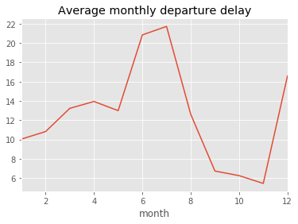

```python
# Your code here
flights_df.groupby('month').dep_delay.mean().plot(title = 'Average monthly departure delay')
plt.show()
```

(d) On average, how do departure delays vary over the course of a day?

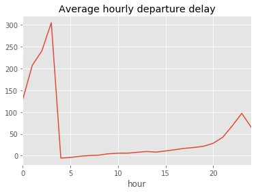

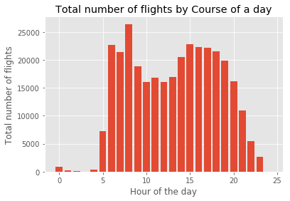

```python
flights_df.groupby('hour').dep_delay.mean().plot(title = "Average hourly departure delay")
plt.show()

plt.bar(range(len(flights_df.groupby('hour').count())), flights_df.groupby('hour').count()['Unnamed: 0'])
plt.xlabel('Hour of the day')
plt.ylabel('Total number of flights')
plt.title('Total number of flights by Course of a day')
plt.show()
```

On an average, the morning hours between 12AM and 3AM have the maximum departure delay. It drops steeply at 4AM and then uniformly rises till about 8PM in the night. After this, there again seems to be a rapid rise till about 11PM before declining again at 12AM.

However, the number of flights from 12 AM to 4AM is very low and the high average departure delay can be considered as outliers compared to the rest of the day.

## Question 3

```
Which flight departing NYC in 2013 flew the fastest?
```

```python
flights_df['speed'] = flights_df.distance*60 / flights_df.air_time
columns = ['carrier', 'tailnum', 'flight', 'origin', 'dest','date', 'speed']
flights_df.sort_values(['speed'], ascending=False)[columns].head(1)
```

|  | carrier | tailnum | flight | origin | dest | date | speed |
| --- | --- | --- | --- | --- | --- | --- | --- |
| 216447 | DL | N666DN | 1499 | LGA | ATL | 2013-05-25 | 703.384615 |

The fastest flight to depart NYC was Delta Airline flight 1499 flying from LaGuardia Airport to Atlanta International airport on 25th May 2013. It was flying at 703.38 miles per hour.

## Question 4

Which flights (i.e. carrier + flight + dest) happen every day? Where do they fly to?

```python
# Your code here
flight_count_carrier_flight_dest = flights_df.groupby(['carrier', 'flight', 'dest']).size()
everyday_flights = flight_count_carrier_flight_dest[flight_count_carrier_flight_dest/365==1]
everyday_flights = everyday_flights.index.values.tolist()

destinations = []
for flight in everyday_flights:
    destination = flight[2]
    if(destination not in destinations):
        destinations.append(destination)

print("Everyday flights are:")
for flight in everyday_flights:
    print(flight[0], flight[1], flight[2])

print("\nDestinations flown to by the flights are:")
for destination in destinations:
    print(destination)
```

```
Everyday flights are:
AA 59 SFO
AA 119 LAX
AA 181 LAX
AA 1357 SJU
AA 1611 MIA
B6 219 CLT
B6 359 BUR
B6 371 FLL
B6 431 SRQ
B6 703 SJU
B6 1783 MCO
DL 2159 MCO
DL 2391 TPA
EV 5712 IAD
UA 15 HNL
VX 251 LAS
VX 407 LAX
VX 413 LAX

Destinations flown to by the flights are:
SFO
LAX
SJU
MIA
CLT
BUR
FLL
SRQ
MCO
TPA
IAD
HNL
LAS
```

The above combinations of carrier, flight and dest happen everyday. The dest attribute tells us the destinations they fly to.

## Question 5

Develop one research question you can address using the nycflights2013 dataset. Provide two visualizations to support your exploration of this question. Discuss what you find.

Research question: Is there a seasonal variation in the choice of a carrier when flying from NYC to Seattle?

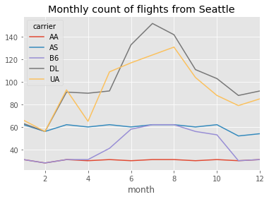

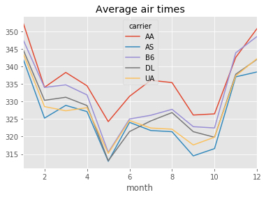

```python
flights_df.loc[flights_df['dest'] == 'SEA'].groupby(['carrier','month']).size().unstack('carrier').plot(title = "Monthly count of flights from Seattle")

flights_df.loc[flights_df['dest'] == 'SEA'].groupby(['carrier','month']).air_time.mean().unstack('carrier').plot(title = "Average air times")
plt.show()
```

From the second plot, we can see that Alaska Air is the fastest carrier for most part of the year, but in the month of March and June it is beaten by United Air and Delta air respectively.

## Question 6

What weather conditions are associated with flight delays leaving NYC? Use graphics to explore.

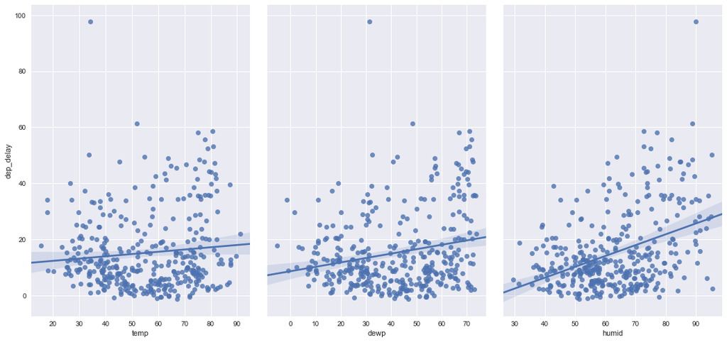

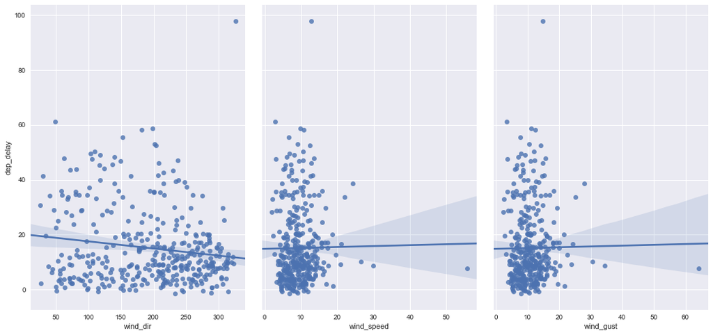

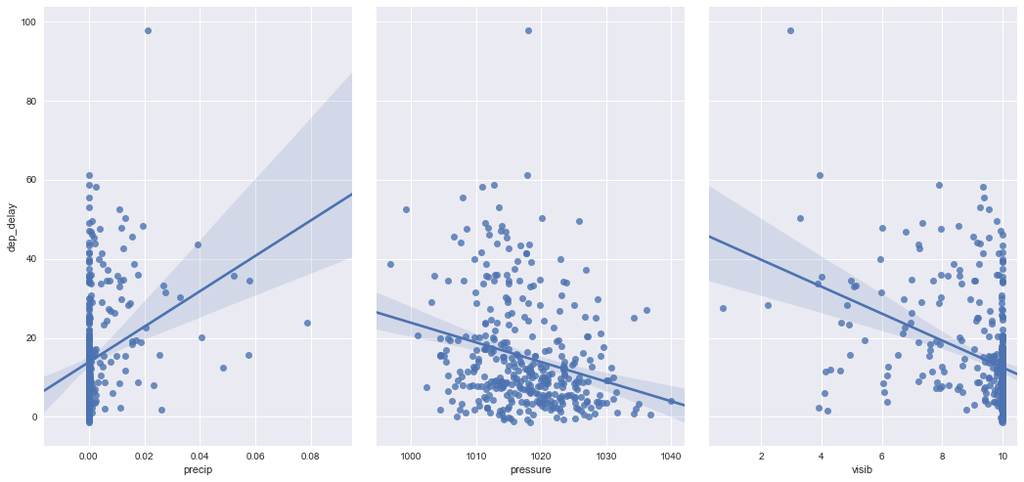

```python
weather_data = pd.read_csv("weather.csv")
weather_df = weather_data.groupby(['year','month','day','origin']).mean()
weather_df.reset_index(level = 0, inplace = True)
weather_df.reset_index(level = 0, inplace = True)
weather_df.reset_index(level = 0, inplace = True)
weather_df.reset_index(level = 0, inplace = True)

flights_agg_mean = flights_df.groupby(['year','month','day','origin']).mean()
flights_agg_mean.reset_index(level = 0, inplace = True)
flights_agg_mean.reset_index(level = 0, inplace = True)
flights_agg_mean.reset_index(level = 0, inplace = True)
flights_agg_mean.reset_index(level = 0, inplace = True)

flights_weather_merge = pd.merge(flights_agg_mean, weather_df, on=['year','month','day','origin'], how='inner')

import seaborn as sns
%matplotlib inline

sns.pairplot(flights_weather_merge, x_vars = ['temp','dewp','humid'], y_vars = 'dep_delay', size = 7,
             aspect = 0.7, kind='reg')
sns.pairplot(flights_weather_merge, x_vars = ['wind_dir', 'wind_speed','wind_gust'], y_vars = 'dep_delay', size = 7,
             aspect = 0.7, kind='reg')
sns.pairplot(flights_weather_merge, x_vars = ['precip', 'pressure','visib'], y_vars = 'dep_delay', size = 7,
             aspect = 0.7, kind='reg')
```

```python
from sklearn.linear_model import LinearRegression
x = flights_weather_merge[['temp','precip','humid','visib']]
y = flights_weather_merge['dep_delay']
linreg = LinearRegression()
linreg.fit(x, y)
print (linreg.intercept_)
print (linreg.coef_)
list(zip(['temp','precip','humid','visib'], linreg.coef_))
```

```
16.1850817975
[  5.15138479e-02   1.83511384e+02   1.94135546e-01  -1.80366646e+00]
```

```
[('temp', 0.051513847934673229),
 ('precip', 183.51138351917945),
 ('humid', 0.1941355459688702),
 ('visib', -1.8036664620825917)]
```

The slope values for each of the predictors represent the change in departure delay if the predictor variable is increased by 1 unit. The intercept is 16.18 units.